# U-Net for Image Classification

```python
from google.colab import drive
drive.mount('/content/drive')
```

# Project Overview

```python
import matplotlib.pyplot as plt
import matplotlib.image as mpimg
```

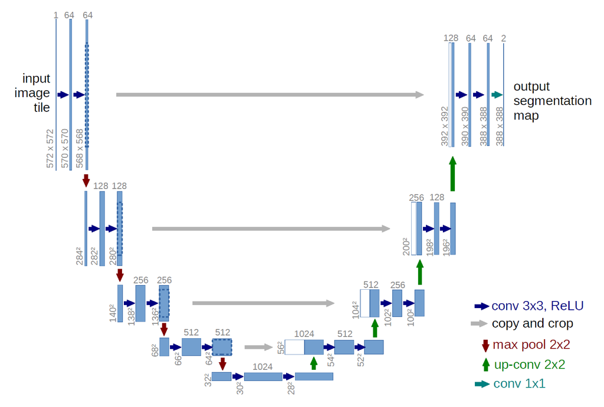

```python
# Specify the path to your image file
image_path = 'UNET_architecture.png'

# Load the image using matplotlib's imread function
img = mpimg.imread(image_path)

# Create a larger figure with higher DPI
plt.figure(figsize=(10, 8), dpi=300)

plt.imshow(img, interpolation='nearest')
plt.axis('off')
plt.show()
```

## 2. Build U-Net Architecture

The U-Net model is constructed using PyTorch, featuring an encoder-decoder structure with skip connections. Key components include:

- **Encoder (Downsampling Path):** Sequential convolutional blocks reduce the spatial dimensions while increasing the feature depth.
- **Bottleneck:** The lowest resolution is processed here, allowing the network to learn the most abstract features.
- **Decoder (Upsampling Path):** Transposed convolutions are used to increase spatial dimensions, paired with skip connections from the encoder to preserve high-resolution details.
- **Final Layer:** The output of the last upsampling step is passed through a convolutional layer to map the deep feature maps to the desired output channels.

```python
import torch
import torch.nn as nn
import torchvision.transforms.functional as TF
```

```python
class DoubleConv(nn.Module):
    def __init__(self, in_channels, out_channels):
        super(DoubleConv, self).__init__()
        self.conv = nn.Sequential(
            nn.Conv2d(in_channels, out_channels, 3, 1, 1, bias=False), # Same conv
            nn.BatchNorm2d(out_channels), # NOT IN THE PAPER! (batch norm paper came out after U-Net, but it can only make it better:)
            nn.ReLU(inplace=True),
            nn.Conv2d(out_channels, out_channels, 3, 1, 1, bias=False),
            nn.BatchNorm2d(out_channels),
            nn.ReLU(inplace=True)
        )

    def forward(self,x):
        return self.conv(x)
```

```python
class UNET(nn.Module):
    def __init__(self, in_channels=3, out_channels=1, features=[64, 128, 256, 512]):
        super(UNET, self).__init__()
        self.ups = nn.ModuleList()
        self.downs = nn.ModuleList()
        self.pool = nn.MaxPool2d(kernel_size=2, stride=2)

        # Down part of UNET
        for feature in features:
            self.downs.append(DoubleConv(in_channels, feature))
            in_channels = feature

        # Up part of UNET
        for feature in reversed(features):
            self.ups.append(
                nn.ConvTranspose2d(
                    feature*2, feature, kernel_size=2, stride=2,
                )
            )
            self.ups.append(DoubleConv(feature*2, feature))

        # Bottleneck
        self.bottleneck = DoubleConv(features[-1], features[-1]*2)

        # Final layer
        self.final_conv = nn.Conv2d(features[0], out_channels, kernel_size=1)

    def forward(self, x):
        skip_connections = []
        for down in self.downs:
            x = down(x)
            skip_connections.append(x)
            x = self.pool(x)

        x = self.bottleneck(x)
        skip_connections = skip_connections[::-1]

        for idx in range(0, len(self.ups), 2): # Up & DoubleConv is a single step. That is why we are using a step of 2
            x = self.ups[idx](x)
            skip_connection = skip_connections[idx//2]

            if x.shape != skip_connection.shape:# reshape
                x = TF.resize(x, size=skip_connection.shape[2:]) # only need height and the width

            concat_skip = torch.cat((skip_connection, x), dim=1)
            x = self.ups[idx+1](concat_skip)

        return self.final_conv(x)
```

One problem that could occur: Lets say the input layer is 161x161. The max pool will going to floor the div by 2 and create an 80x80. Then, during the up sample it will create an output of 160x160. This means we won't be able to concatenate the two.

To solve this, always choose an input that is divisible by 16.

```python
def check_size():
    x = torch.randn((3, 1, 161, 161))
    model = UNET(in_channels=1, out_channels=1)
    preds = model(x)
    print(preds.shape)
    print(x.shape)
    assert preds.shape == x.shape

if __name__ == "__main__":
    check_size()
```

```
torch.Size([3, 1, 161, 161])
torch.Size([3, 1, 161, 161])
```

## 2. Try Image Segmentation

Using the U-Net model, perform image segmentation on a dataset. The process involves three main steps:

### Dataset Preparation

- **Objective:** Load and preprocess the dataset suitable for segmentation tasks.
- **Details:** Choose datasets that are commonly used for segmentation tasks, such as medical images (e.g., MRI or CT scans) or satellite images.
- **Preprocessing Steps:** Include normalization, resizing images to a consistent dimension, and possibly augmenting the dataset to improve model robustness.

### Training

- **Objective:** Train the U-Net model on the prepared dataset.
- **Loss Function:** Use an appropriate loss function for segmentation. Common choices include:
  - **Dice Loss:** Useful for dealing with class imbalance in images.
  - **Cross-Entropy Loss:** Standard loss for segmentation tasks.
- **Optimization:** Use optimizers like Adam or SGD to minimize the loss function.

### Evaluation

- **Objective:** Validate the model's performance on a separate test set.
- **Metrics:** Evaluate the model using segmentation-specific metrics such as:
  - **IoU (Intersection over Union):** Measures the overlap between the predicted segmentation and the ground truth.
  - **Dice Coefficient:** Similar to IoU, useful for assessing the quality of the segmentation.

First, we are going to download the dataset for Carvana Image Masking Challenge

```python
import os
from PIL import Image
from torch.utils.data import Dataset
import numpy as np
import torchvision
```

```python
class CarvanaDataset(Dataset):
    def __init__(self, image_dir, mask_dir, transform=None):
        self.image_dir = image_dir
        self.mask_dir = mask_dir
        self.transform = transform
        self.images = os.listdir(image_dir)

    def __len__(self):
        return len(self.images)

    def __getitem__(self, index):
        img_path = os.path.join(self.image_dir, self.images[index])
        mask_path = os.path.join(self.mask_dir, self.images[index].replace(".jpg", "_mask.gif"))
        image = np.array(Image.open(img_path).convert("RGB"))
        mask = np.array(Image.open(mask_path).convert("L"), dtype=np.float32) # Greyscale image
        mask[mask == 255.0] = 1.0 # becuase we are going to use sigmoid as our last activation

        if self.transform is not None:
            augmentations = self.transform(image=image, mask=mask)
            image = augmentations["image"]
            mask = augmentations["mask"]

        return image, mask
```

```python
import torch
import albumentations as A
from albumentations.pytorch import ToTensorV2
from tqdm import tqdm
import torch.nn as nn
import torch.optim as optim
from torch.utils.data import DataLoader
```

```python
def save_checkpoint(state, filename="my_checkpoint.pth.tar"):
    print("=> Saving Checkpoint")
    torch.save(state, filename)

def load_checkpoint(checkpoint, model):
    print("=> Loading checkpoint")
    model.load_state_dict(checkpoint["state_dict"])
```

```python
def get_loaders(
    train_dir,
    train_maskdir,
    val_dir,
    val_maskdir,
    batch_size,
    train_transform,
    val_transform,
    num_workers=4,
    pin_memory=True,
):
    train_ds = CarvanaDataset(
        image_dir=train_dir,
        mask_dir=train_maskdir,
        transform=train_transform,
    )

    train_loader = DataLoader(
        train_ds,
        batch_size=batch_size,
        num_workers=num_workers,
        pin_memory=pin_memory,
        shuffle=True,
    )

    val_ds = CarvanaDataset(
        image_dir=val_dir,
        mask_dir=val_maskdir,
        transform=val_transform,
    )

    val_loader = DataLoader(
        val_ds,
        batch_size=batch_size,
        num_workers=num_workers,
        pin_memory=pin_memory,
        shuffle=False,
    )

    return train_loader, val_loader
```

```python
def check_accuracy(loader, model, device="cuda"):
    num_correct = 0
    num_pixels = 0
    dice_score = 0
    model.eval()

    with torch.no_grad():
        for x, y in loader:
            x = x.to(device)
            y = y.to(device).unsqueeze(1)
            preds = torch.sigmoid(model(x))
            preds = (preds > 0.5).float()
            num_correct += (preds == y).sum()
            num_pixels += torch.numel(preds)
            dice_score += (2 * (preds * y).sum()) / (
                (preds + y).sum() + 1e-8
            )

    print(
        f"Got {num_correct}/{num_pixels} with acc {num_correct/num_pixels*100:.2f}"
    )
    print(f"Dice score: {dice_score/len(loader)}")
    model.train()
```

```python
def save_predictions_as_imgs(loader, model, folder="saved_images/", device="cuda"):
    model.eval()
    for idx, (x, y) in enumerate(loader):
        x = x.to(device=device)
        with torch.no_grad():
            preds = torch.sigmoid(model(x))
            preds = (preds > 0.5).float()
        torchvision.utils.save_image(
            preds, f"{folder}/pred_{idx}.png"
        )
        torchvision.utils.save_image(y.unsqueeze(1), f"{folder}{idx}.png")

    model.train()
```

```python
import torch
import albumentations as A
from albumentations.pytorch import ToTensorV2
from tqdm import tqdm
import torch.nn as nn
import torch.optim as optim
```

```python
# Hyperparameters etc.
LEARNING_RATE = 1e-4
DEVICE = "cuda" if torch.cuda.is_available() else "cpu"
BATCH_SIZE = 16
NUM_EPOCHS = 3
NUM_WORKERS = 2
IMAGE_HEIGHT = 160  # 1280 originally
IMAGE_WIDTH = 240  # 1918 originally
PIN_MEMORY = True
LOAD_MODEL = False
TRAIN_IMG_DIR = "drive/MyDrive/data/train_images/"
TRAIN_MASK_DIR = "drive/MyDrive/data/train_masks/"
VAL_IMG_DIR = "drive/MyDrive/data/val_images/"
VAL_MASK_DIR = "drive/MyDrive/data/val_masks/"
```

```python
def train_fn(loader, model, optimizer, loss_fn, scaler): # going to do 1 epoch of training
    loop = tqdm(loader)

    for batch_idx, (data, targets) in enumerate(loop):
        data = data.to(device=DEVICE)
        targets = targets.float().unsqueeze(1).to(device=DEVICE)

        # forward
        with torch.cuda.amp.autocast():
            predictions = model(data)
            loss = loss_fn(predictions, targets)

        # backward
        optimizer.zero_grad()
        scaler.scale(loss).backward()
        scaler.step(optimizer)
        scaler.update()

        # update tqdm loop
        loop.set_postfix(loss=loss.item())
```

```python
def main():
    train_transform = A.Compose( # train data
        [
            A.Resize(height=IMAGE_HEIGHT, width=IMAGE_WIDTH),
            A.Rotate(limit=35, p=1.0),
            A.HorizontalFlip(p=0.5),
            A.VerticalFlip(p=0.1),
            A.Normalize(
                mean=[0.0, 0.0, 0.0],
                std=[1.0, 1.0, 1.0],
                max_pixel_value=255.0, # value between 0 and 1
            ),
            ToTensorV2(),
        ],
    )

    val_transforms = A.Compose( # validation data
        [
            A.Resize(height=IMAGE_HEIGHT, width=IMAGE_WIDTH),
            A.Normalize(
                mean=[0.0, 0.0, 0.0],
                std=[1.0, 1.0, 1.0],
                max_pixel_value=255.0,
            ),
            ToTensorV2(),
        ],
    )

    model = UNET(in_channels=3, out_channels=1).to(DEVICE)
    loss_fn = nn.BCEWithLogitsLoss() # change for multiclass
    optimizer = optim.Adam(model.parameters(), lr=LEARNING_RATE)

    train_loader, val_loader = get_loaders(
        TRAIN_IMG_DIR,
        TRAIN_MASK_DIR,
        VAL_IMG_DIR,
        VAL_MASK_DIR,
        BATCH_SIZE,
        train_transform,
        val_transforms,
        NUM_WORKERS,
        PIN_MEMORY,
    )

    if LOAD_MODEL:
        load_checkpoint(torch.load("my_checkpoint.pth.tar"), model)


    check_accuracy(val_loader, model, device=DEVICE)
    scaler = torch.cuda.amp.GradScaler()

    for epoch in range(NUM_EPOCHS):
        train_fn(train_loader, model, optimizer, loss_fn, scaler)

        # save model
        checkpoint = {
            "state_dict": model.state_dict(),
            "optimizer":optimizer.state_dict(),
        }
        save_checkpoint(checkpoint)

        # check accuracy
        check_accuracy(val_loader, model, device=DEVICE)

        # print some examples to a folder
        save_predictions_as_imgs(
            val_loader, model, folder="drive/MyDrive/", device=DEVICE
        )
```

```python
main()
```

```
Got 30820348/39091200 with acc 78.84
Dice score: 0.0
```

```
=> Saving Checkpoint
Got 38312900/39091200 with acc 98.01
Dice score: 0.9542471170425415
```

```
=> Saving Checkpoint
Got 38717418/39091200 with acc 99.04
Dice score: 0.9777600765228271
```

```
=> Saving Checkpoint
Got 38839229/39091200 with acc 99.36
Dice score: 0.9848598837852478
```

## 3. Modify the Code for Image Classification

To adapt the U-Net model for image classification tasks, follow these modifications:

### Adapt Network Structure

- **Objective:** Modify the U-Net model to output class probabilities.
- **Modifications:**
  - Add a global average pooling layer after the last convolutional layer to reduce each feature map to a single number.
  - Append a fully connected layer (or layers) that outputs the probability for each class.

### Change Loss Function

- **Objective:** Utilize a suitable loss function for classification.
- **Loss Function:** For multi-class classification, use **Cross-Entropy Loss**, which is well-suited for discrete probability distributions.

### Output Adjustments

- **Objective:** Ensure the model outputs match the number of target classes.
- **Details:**
  - Adjust the final layer to have as many outputs as there are classes.
  - Use a softmax activation function in the final layer to ensure the output values represent probabilities.